# Checking combination-response models

Teo Sakel

2026-08-04

## Purpose

Model checks ask whether replicated data from a fitted model resemble the observations in scientifically relevant ways. No single plot can validate a model. A useful workflow combines pooled distribution checks, calibration, conditional checks, and residual patterns. The choices below follow the [recommendations for visual predictive checks](https://teemusailynoja.github.io/visual-predictive-checks/).

`batchieR` currently uses a homoscedastic Gaussian likelihood with an identity link. The checks therefore operate on the response scale supplied to `fit_combo()`. Transform bounded viability before fitting, and interpret plots on that transformed scale.

```r
library(batchieR)
set.seed(20260804L)
```

## A diagnostic example

The synthetic screen has three cells, three compounds, two doses, and replicate single and combination experiments. Its response includes a cell-dependent combination interaction. We fit the data twice: the full model can represent that interaction, while the additive model deliberately omits it.

```r
cells <- c("A", "B", "C")
drugs <- c("X", "Y", "Z")
doses <- 1:2

singles <- expand.grid(
    cell = cells,
    drug_1 = drugs,
    dose_1 = doses,
    replicate = 1:2,
    stringsAsFactors = FALSE
)
singles$drug_2 <- NA_character_
singles$dose_2 <- NA_real_
singles$experiment_type <- "single"

pairs <- expand.grid(
    cell = cells,
    pair = c("X:Y", "X:Z", "Y:Z"),
    dose_1 = doses,
    dose_2 = doses,
    replicate = 1:2,
    stringsAsFactors = FALSE
)
pair_parts <- strsplit(pairs$pair, ":", fixed = TRUE)
pairs$drug_1 <- vapply(pair_parts, `[`, character(1), 1L)
pairs$drug_2 <- vapply(pair_parts, `[`, character(1), 2L)
pairs$pair <- NULL
pairs$experiment_type <- "combination"

screen <- rbind(
    singles[c(
        "cell", "drug_1", "dose_1", "drug_2", "dose_2",
        "replicate", "experiment_type"
    )],
    pairs[c(
        "cell", "drug_1", "dose_1", "drug_2", "dose_2",
        "replicate", "experiment_type"
    )]
)
screen$plate <- paste0(screen$experiment_type, "_", screen$replicate)

cell_offset <- c(A = -0.15, B = 0.10, C = 0.25)
cell_loading <- c(A = 1.0, B = -0.8, C = 0.35)
drug_offset <- c(X = -0.35, Y = -0.55, Z = -0.20)
interaction_loading <- c(X = 1.0, Y = -0.9, Z = 0.7)

eta <- 0.7 + cell_offset[screen$cell] +
    drug_offset[screen$drug_1] - 0.12 * screen$dose_1
has_second <- !is.na(screen$drug_2)
eta[has_second] <- eta[has_second] +
    drug_offset[screen$drug_2[has_second]] -
    0.12 * screen$dose_2[has_second] +
    cell_loading[screen$cell[has_second]] *
    interaction_loading[screen$drug_1[has_second]] *
    interaction_loading[screen$drug_2[has_second]]

screen$response <- eta + stats::rnorm(nrow(screen), sd = 0.15)
```

```r
full_model <- combo_model(
    rank = 1L,
    treatment_main_factors = NULL
)
additive_model <- combo_model(
    rank = 1L,
    cell_factors = NULL,
    treatment_main_factors = NULL,
    treatment_interaction_factors = NULL
)

full_fit <- fit_combo(
    full_model,
    screen,
    chains = 2L,
    iter_warmup = 50L,
    iter_sampling = 100L,
    seed = 20260804L
)
additive_fit <- fit_combo(
    additive_model,
    screen,
    chains = 2L,
    iter_warmup = 50L,
    iter_sampling = 100L,
    seed = 20260805L
)
```

These short runs keep the vignette portable. Before interpreting checks from a real analysis, run enough chains and iterations to establish convergence and adequate effective sample sizes. Posterior predictive checks do not diagnose a sampler that has failed to explore the posterior.

## Start with pooled distributions

An ECDF overlay is a robust first look at location, spread, and tails. The dark observed curve should look like a plausible member of the replicated curves. A pooled match is necessary but not sufficient: discrepancies can cancel across cells or experiment types.

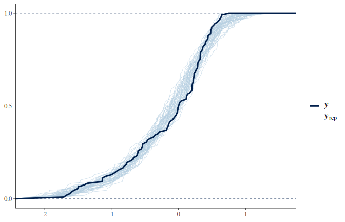

```r
bayesplot::pp_check(full_fit, type = "ecdf_overlay")
```

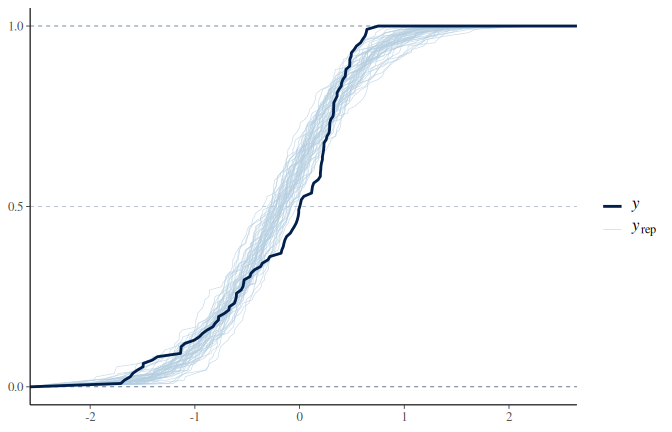

```r
bayesplot::pp_check(additive_fit, type = "ecdf_overlay")
```

Density overlays are convenient only when the response distribution is smooth and continuous. Kernel smoothing can hide rounding, censoring, strict bounds, or point masses. Use an ECDF when those features are possible; a warning from a density check is a prompt to inspect the data representation, not proof that the fitted model is wrong.

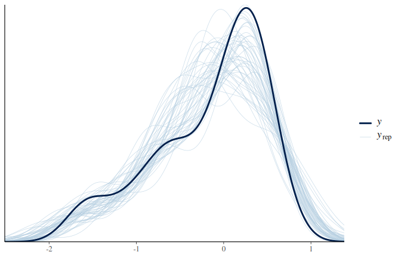

```r
bayesplot::pp_check(full_fit, type = "dens_overlay")
```

## Check out-of-sample calibration

LOO-PIT reweights posterior draws to approximate leaving each fitted observation out. The ECDF difference should remain within the simultaneous bands when the pointwise predictive distributions are calibrated. Broad U-shaped PIT behavior indicates predictions that are too narrow, central concentration indicates predictions that are too wide, and asymmetry indicates location bias.

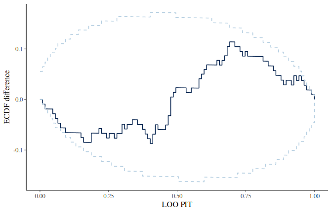

```r
bayesplot::pp_check(full_fit, type = "loo_pit")
```

```
#> 'pit' specified so ignoring 'y','yrep','lw' if specified.
```

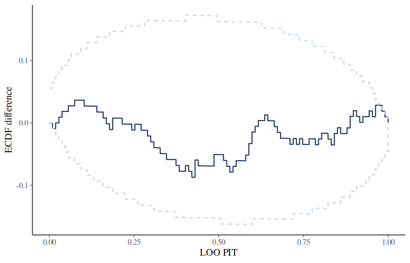

```r
bayesplot::pp_check(additive_fit, type = "loo_pit")
```

PSIS is an approximation. If the check warns about Pareto `k`, inspect the influential observations before trusting the bands.

```r
full_loo <- loo::loo(full_fit)
```

```
#> Warning: Some Pareto k diagnostic values are too high. See help('pareto-k-diagnostic') for details.
```

```r
loo::pareto_k_table(full_loo)
```

```
#> Pareto k diagnostic values:
#>                           Count Pct.    Min. ESS
#> (-Inf, 0.57]   (good)     102   94.4%   1
#>    (0.57, 1]   (bad)        6    5.6%   <NA>
#>     (1, Inf)   (very bad)   0    0.0%   <NA>
```

Large `k` can mean that an observation is influential, that the posterior has problematic tails, or that exact leave-one-out refitting is needed. It is not by itself a statement about biological importance.

## Condition on screen structure

Pooling can hide a model that fits single treatments while missing combinations. Passing a column name to `group` keeps it aligned with observed rows, including when some source rows have missing responses.

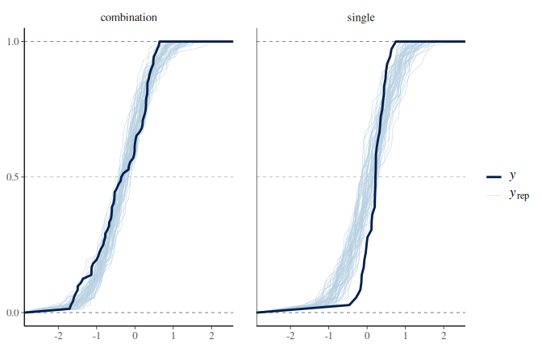

```r
bayesplot::pp_check(
    additive_fit,
    type = "ecdf_overlay",
    group = "experiment_type"
)
```

A systematic shift confined to combinations points toward an inadequate interaction structure. A shift confined to one cell suggests missing cell-specific structure. Plate-specific shifts can indicate unmodeled batch effects; `plate` is preserved as an extra checking column even though it is not part of the required experiment schema.

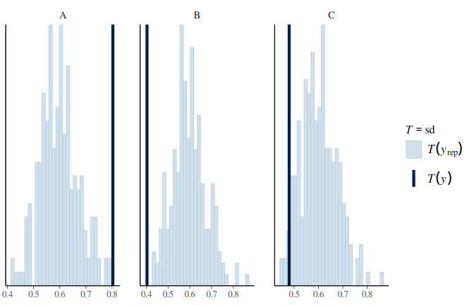

```r
bayesplot::pp_check(
    additive_fit,
    type = "stat",
    stat = "sd",
    group = "cell"
)
```

For each facet, the observed statistic should fall in a plausible part of the replicated distribution. Small groups produce noisy checks, so combine visual extremeness with domain knowledge and sample size.

## Inspect predictive errors

Predictive errors are observed minus replicated response, summarized over posterior draws. Positive errors indicate systematic underprediction; negative errors indicate overprediction. A cloud centered on zero without structure is the desired pattern.

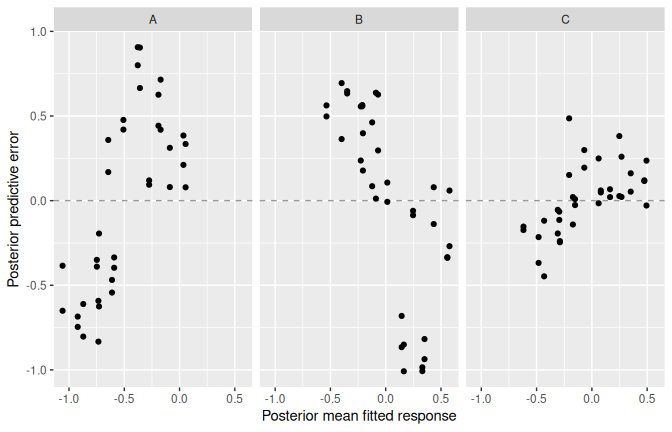

```r
bayesplot::pp_check(additive_fit, type = "error", group = "cell")
```

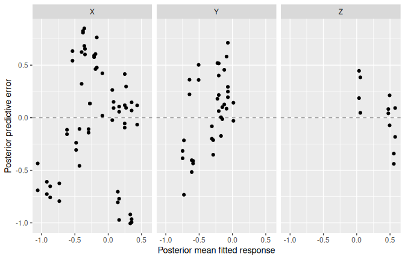

```r
bayesplot::pp_check(
    additive_fit,
    type = "error",
    group = "drug_1"
)
```

Here `drug_1` is categorical, so it defines residual-versus-fitted panels for compound-specific bias rather than a numeric x-axis. Grouping by `dose_1` is a useful alternative when the scientific question is dose-specific bias; because dose is categorical in this model, it should likewise be grouped rather than used as a continuous x-axis.

Curvature or a nonzero trend suggests mean-model misspecification. A fan-shaped change in spread suggests heteroscedasticity, which the current Gaussian family cannot represent. A group-specific offset suggests a missing cell, treatment, interaction, plate, or covariate effect.

## Check dispersion and tails explicitly

The mean alone is usually a weak statistic. Joint statistics ask whether the observed location and spread are jointly plausible.

```
#> Note: in most cases the default test statistic 'mean' is too weak to detect anything of interest.
```

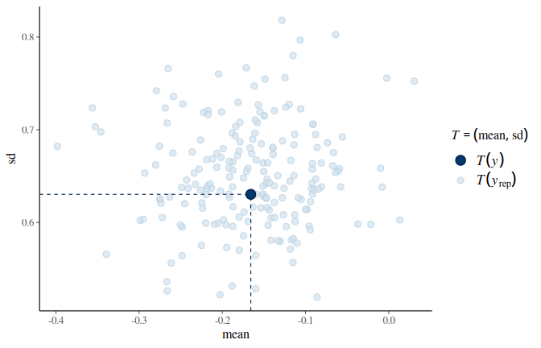

```r
bayesplot::pp_check(
    additive_fit,
    type = "stat_2d",
    stat = c("mean", "sd")
)
```

Repeat one-dimensional checks with scientifically meaningful tail summaries, for example `mad`, a lower quantile, or an upper quantile. The statistic may be a function returning one finite number.

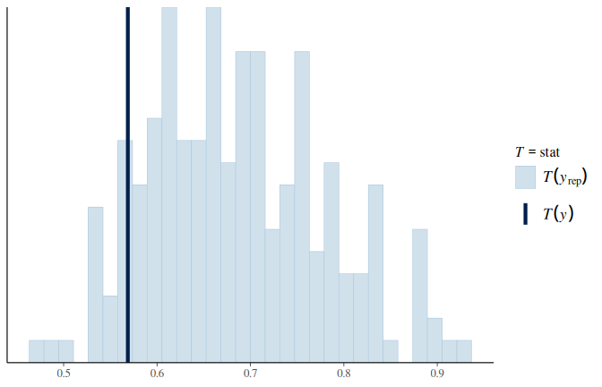

```r
upper_tail <- function(x) unname(stats::quantile(x, 0.95))
bayesplot::pp_check(full_fit, type = "stat", stat = upper_tail)
```

Intervals locate individual observations for which predictive uncertainty and observed values disagree. With many rows, subset to a meaningful plate or sort by a useful numeric covariate instead of relying on row order.

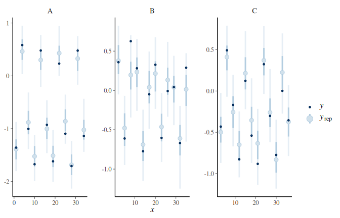

```r
interval_data <- screen[screen$plate == "combination_1", ]
bayesplot::pp_check(
    full_fit,
    type = "intervals",
    newdata = interval_data,
    x = seq_len(nrow(interval_data)),
    group = "cell"
)
```

## From patterns to action

| Pattern | Likely issue | Next action |
| --- | --- | --- |
| Pooled curves shifted | Global location mismatch | Revisit transformation, intercept, and response scale |
| Observed distribution too narrow or wide | Dispersion mismatch | Revisit Gaussian scale or likelihood family |
| Only one cell or experiment type fails | Conditional mean misspecification | Add or revise the corresponding component or covariate |
| Residual trend against dose | Dose relationship misspecification | Revisit categorical versus nested dose structure |
| Combination-only residual shift | Missing interaction structure | Add or increase interaction capacity |
| Tail statistic is extreme | Tail or outlier mismatch | Inspect assay limits, contamination, and likelihood tails |
| LOO-PIT leaves its bands | Pointwise predictive miscalibration | Diagnose shape, then inspect conditional checks |
| Large Pareto `k` | Unreliable PSIS approximation or influential row | Inspect the row and consider exact refitting |

A model that passes these checks is not proven correct. It is a model for which these chosen discrepancies were not detected at the available sample size. Record the checks selected before comparing many alternatives, and validate any major statistical change with simulation or parameter recovery.